# The Systematic Gender Gap in STEM Fields: Why Should We Care?

Julia Keith and Annie Glassie

Sunday December 18th, 2016

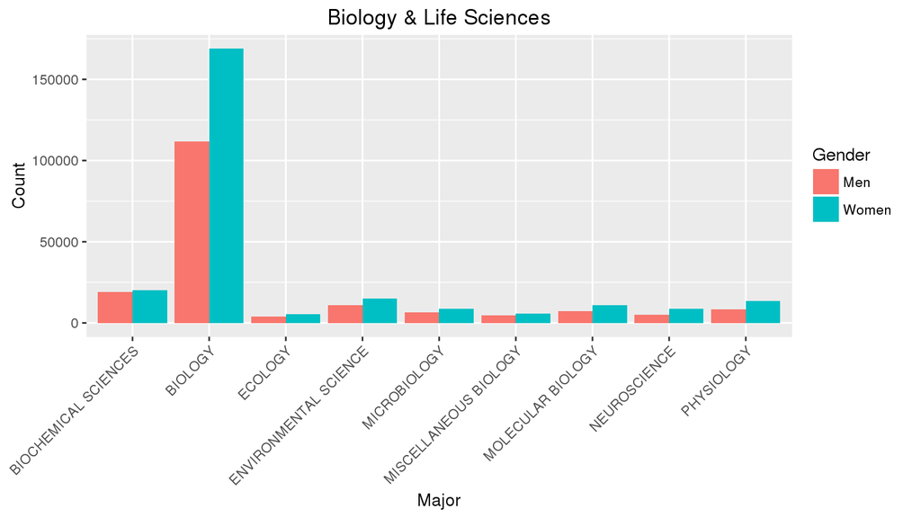

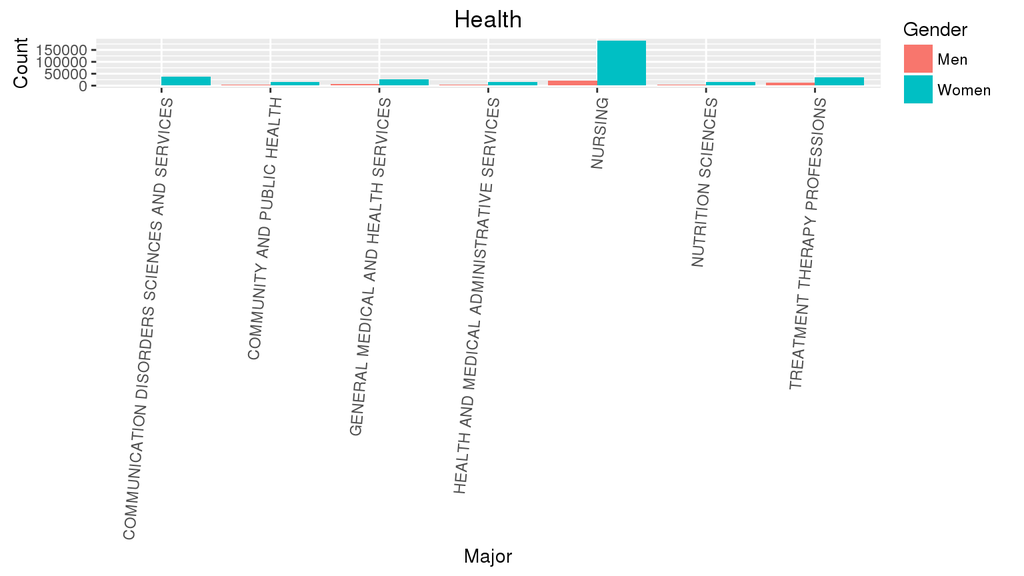

******

While more than sixty percent of biology majors are female, men continue to dominate the STEM fields (Eddy). The data summarized in the graphs titled “Health” and “Biology & Life Sciences” explicitly show that women outnumber men in these STEM realms. The graph “Health” explicitly shows that women earn the majority share of degrees in all seven majors related to physical health, most notably in nursing. Secondly, across all majors that fall under the umbrella of biology and life science, women earn the majority of degrees, most dominantly in the biology major. Judging from the strikingly high proportion of women majoring in biology, one may jump to the conclusion that the gender gap in this particular STEM discipline simply does not exist; researchers from Arizona State University conducted a national study to challenge the legitimacy of this conclusion (Eddy). The researchers found “evidence of gender-based gaps in both achievement and class participation” to be present in biology courses across the country (Eddy). In terms of the gender-based achievement gap, the research proved that “female [biology] students had average exam scores of 2.8 percent lower than male students” (Eddy). This gap in performance is likely stimulated by the lack of female voices in the classroom. Researchers found that 63% of those who volunteered their answers most frequently were men, despite males comprising only 40% of the total number of students in a given classroom (Eddy). One researcher stated plainly that “if females aren’t heard as often as males, they don’t have the same opportunity to succeed as biology majors.”(Eddy) In a nation where women have earned the majority of doctoral degrees for the 7th year in a row, female physicians make an average of $51,315 less than their male counterparts each year (Perry) (Caplan-Bricker). These known facts coincide with our data that displays women obtaining the majority of biology degrees, yet failing to level the playing field with men in STEM careers collectively. How is it that women, who are of majority presence in the field of biology, hold less than 25% of all STEM related jobs? (Beede) In search for an answer, researchers and statisticians look to the absence of female students aspiring towards STEM majors such as engineering, physical science and mathematics.

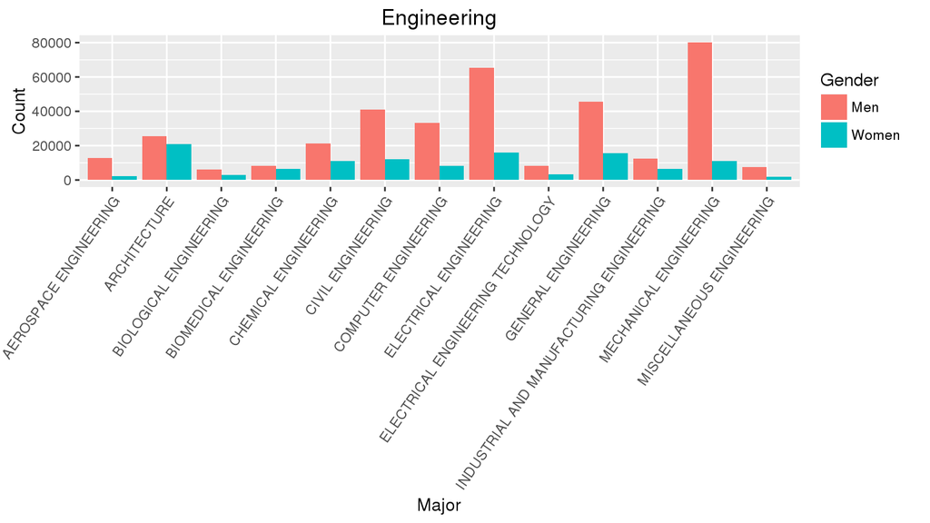

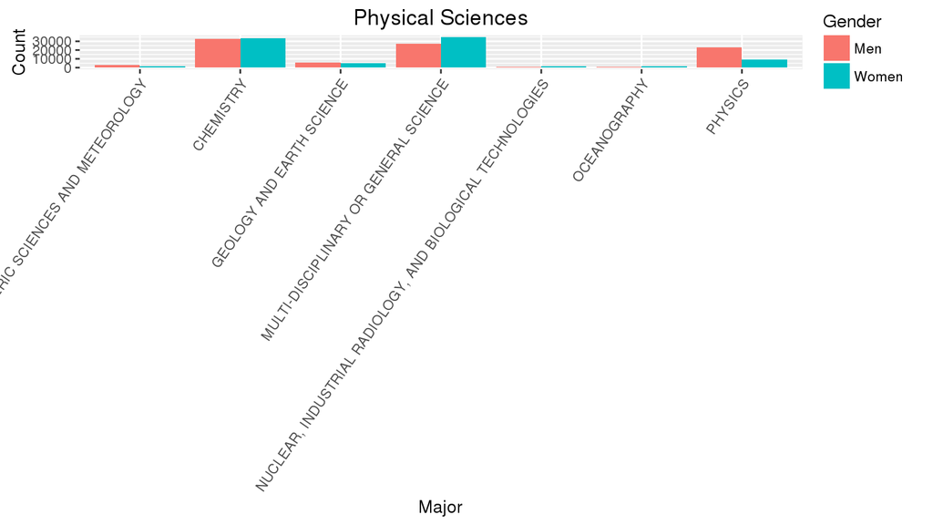

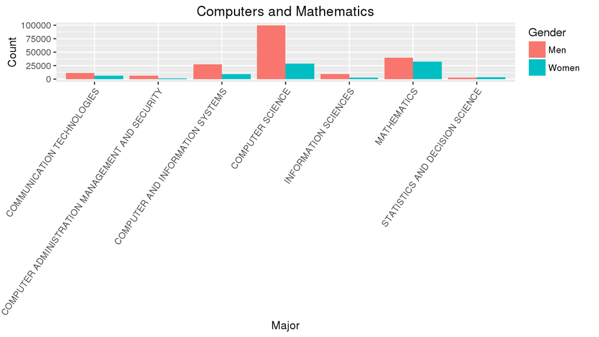

******